# Project2

Nathan Waters, Lerone Williams

Monday, February 16, 2015

In this R Markdown document we will display and document each step of CS329e R Project 2.

Project Requirements http://www.cs.utexas.edu/~cannata/dataVis/Projects/R%20Project%202/R%20Project%20Requirements.html.

In the source folder 01 Data, the R script dataframes.R was created to connect to Dr. Cannata’s Orcale database and generate a data frame from the uploaded Vocabulary.csv file. The RCurl package was loaded to allow general HTTP requests and process the results returned by the Web server.

```r
source("../01 Data/dataframe.R", echo = TRUE)
```

```
##
## > require("RCurl")
```

```
##
## > vocab <- df <- data.frame(eval(parse(text = substring(getURL(URLencode("http://129.152.144.84:5001/rest/native/?query=\"select * from Vocabulary\"") .... [TRUNCATED]
```

A second R script dataframes1.R was created to display the vocab data frame that was previously created in the last step. The head(), tail(), tbl_df(), glimpse(), and summary() functions were used to return subsets of this data frame.

```r
source("../01 Data/dataframe1.R", echo = TRUE)
```

```
##
## > require("dplyr")
```

```
##
## > head(vocab)
##   PARTICIPANT_ID YEAR    SEX EDUCATION VOCABULARY
## 1       20042139 2004   Male        12          6
## 2       20042141 2004   Male        13          6
## 3       20042142 2004 Female        18          7
## 4       20042147 2004   Male        10          5
## 5       20042149 2004   Male        10          7
## 6       20042150 2004 Female        16          6
##
## > tail(vocab)
##       PARTICIPANT_ID YEAR    SEX EDUCATION VOCABULARY
## 21633       19982818 1998   Male        14          4
## 21634       19982819 1998 Female        12          4
## 21635       19982821 1998   Male        12          5
## 21636       19982822 1998   Male        12          5
## 21637       19982825 1998   Male        13          8
## 21638       19982828 1998 Female        14          6
##
## > tbl_df(vocab)
## Source: local data frame [21,638 x 5]
##
##    PARTICIPANT_ID YEAR    SEX EDUCATION VOCABULARY
## 1        20042139 2004   Male        12          6
## 2        20042141 2004   Male        13          6
## 3        20042142 2004 Female        18          7
## 4        20042147 2004   Male        10          5
## 5        20042149 2004   Male        10          7
## 6        20042150 2004 Female        16          6
## 7        20042151 2004 Female        13          9
## 8        20042152 2004   Male        13          4
## 9        20042154 2004 Female        12          5
## 10       20042158 2004   Male        12          6
## ..            ...  ...    ...       ...        ...
##
## > glimpse(vocab)
## Observations: 21638
## Variables:
## $ PARTICIPANT_ID (dbl) 20042139, 20042141, 20042142, 20042147, 2004214...
## $ YEAR           (dbl) 2004, 2004, 2004, 2004, 2004, 2004, 2004, 2004,...
## $ SEX            (fctr) Male, Male, Female, Male, Male, Female, Female...
## $ EDUCATION      (dbl) 12, 13, 18, 10, 10, 16, 13, 13, 12, 12, 11, 14,...
## $ VOCABULARY     (dbl) 6, 6, 7, 5, 7, 6, 9, 4, 5, 6, 5, 9, 8, 6, 6, 4,...
##
## > summary(vocab)
##  PARTICIPANT_ID          YEAR          SEX          EDUCATION
##  Min.   :19740001   Min.   :1974   Female:12312   Min.   : 0.0
##  1st Qu.:19821102   1st Qu.:1982   Male  : 9326   1st Qu.:12.0
##  Median :19891156   Median :1989                  Median :12.0
##  Mean   :19889570   Mean   :1989                  Mean   :12.8
##  3rd Qu.:19960795   3rd Qu.:1996                  3rd Qu.:15.0
##  Max.   :20042811   Max.   :2004                  Max.   :20.0
##    VOCABULARY
##  Min.   : 0.000
##  1st Qu.: 5.000
##  Median : 6.000
##  Mean   : 5.996
##  3rd Qu.: 7.000
##  Max.   :10.000
```

In this data wrangling section, several work flows are constructed using the %>% pipe operator which revealed new information about the data set.

```r
source("../02 Data Wrangling/Data Wrangling.R", echo = TRUE)
```

```
##
## > require("dplyr")
##
## > require("tidyr")
```

```
##
## > head(vocab)
##   PARTICIPANT_ID YEAR    SEX EDUCATION VOCABULARY
## 1       20042139 2004   Male        12          6
## 2       20042141 2004   Male        13          6
## 3       20042142 2004 Female        18          7
## 4       20042147 2004   Male        10          5
## 5       20042149 2004   Male        10          7
## 6       20042150 2004 Female        16          6
##
## > vocab %>% spread(SEX, EDUCATION) %>% tbl_df
## Source: local data frame [21,638 x 5]
##
##    PARTICIPANT_ID YEAR VOCABULARY Female Male
## 1        19740001 1974          9     NA   14
## 2        19740002 1974          9     NA   16
## 3        19740003 1974          9     10   NA
## 4        19740004 1974          5     10   NA
## 5        19740005 1974          8     12   NA
## 6        19740006 1974          8     NA   16
## 7        19740007 1974          9     NA   17
## 8        19740008 1974          5     NA   10
## 9        19740009 1974          3     12   NA
## 10       19740010 1974          5     11   NA
## ..            ...  ...        ...    ...  ...
##
## > vocab %>% group_by(SEX) %>% summarize(Average_Education = mean(EDUCATION)) %>%
## +     tbl_df
## Source: local data frame [2 x 2]
##
##      SEX Average_Education
## 1 Female          12.64352
## 2   Male          12.99517
##
## > vocab %>% group_by(SEX) %>% summarize(Average_Vocabulary = mean(VOCABULARY)) %>%
## +     tbl_df
## Source: local data frame [2 x 2]
##
##      SEX Average_Vocabulary
## 1 Female           6.032732
```

[output cut: 64 more lines]

```
## 6        20042423 2004 Female        14         10
## 7        20042439 2004 Female        14         10
## 8        20042576 2004 Female        18         10
## 9        20042636 2004 Female        12         10
## 10       20042646 2004 Female        15         10
## 11       20042412 2004   Male        13         10
## 12       20042656 2004   Male        12         10
## 13       20040030 2004   Male        16         10
## 14       20040057 2004   Male        16         10
## 15       20040177 2004   Male        18         10
## 16       20040350 2004   Male        16         10
## 17       20040393 2004   Male        12         10
## 18       20040402 2004   Male        16         10
## 19       20040433 2004   Male        16         10
## 20       20040447 2004   Male        11         10
```

Lynda.com provides instructional videos which were utilized to create these visualizations. In particular, R Statistics Essential Training, Ch8. Charts for Three or More Variables.

Link to video: http://www.lynda.com/R-tutorials/R-Statistics-Essential-Training/142447-2.html?srchtrk=index:1%0Alinktypeid:2%0Aq:R%0Apage:1%0As:relevance%0Asa:true%0Aproducttypeid:2

```r
source("../03 Visualizations/hook.R", echo = TRUE)
```

> require(knitr)

> knit_hooks$set(webgl = hook_webgl)

**If you do not see a spinnable 3d plot.** 1. Navigate to the top of the page 2. Click Open in Browser 3. Accept the Allow blocked content warning 4. Scroll down and you should see a spinnable 3d plot of the entire Vocabulary data set. **NOTE: This works for Windows**

```r
source("../03 Visualizations/plot3d.R", echo = TRUE)
```

```
##
## > require("rgl")
```

```
##
## > require("RColorBrewer")
```

```
##
## > plot3d(vocab$YEAR, vocab$EDUCATION, vocab$VOCABULARY,
## +     xlab = "YEAR", ylab = "EDUCATION", zlab = "VOCABULARY", col = rainbow(1000),
## +     siz .... [TRUNCATED]
```

[interactive chart not shown]

This is a scatterplot matrix with hotgrams along the diagonal.

```r
source("../03 Visualizations/Matrix.R", echo = TRUE)
```

```
##
## > panel.hist <- function(x, ...) {
## +     usr <- par("usr")
## +     on.exit(par(usr))
## +     par(usr = c(usr[1:2], 0, 1.5))
## +     h <- hist(x, plot = FALS .... [TRUNCATED]
##
## > pairs(vocab[c(1:5)], panel = panel.smooth, main = "Scatterplot Matrix for Vocabulary and Education Data",
## +     diag.panel = panel.hist, pch = 16,  .... [TRUNCATED]
```

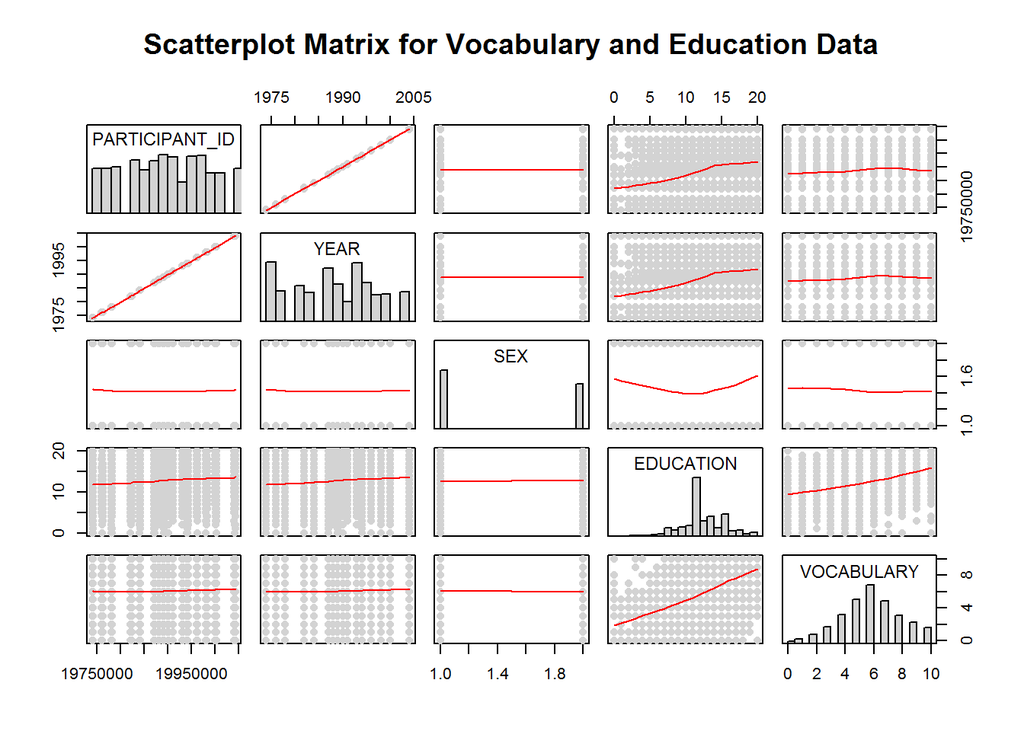